# The Fourier Transform

from *The Analytical Theory of Heat*, Jean-Baptiste Fourier, 1822

## Outline

- History (Tyler)
- Derivation (Tyler)
- Forms (Tyler + Brian)
- Examples (Brian)
- Fourier Neural Operators (Brian + Tyler)

## History

*Seminal work* [1]

- **1801** At Napoleon's request, Fourier leaves his post as scientific advisor in Egypt and enters an administrative position in Grenoble. During this time, he begins researching heat propagation.
- **1807** Fourier presents his paper on heat propagation to the Paris Institute. First use of the Fourier Series.
- **1815** Fourier returns to Paris following the Battle of Waterloo and devotes himself to writing *The Analytical Theory of Heat*
- **1822** Fourier's work is published, detailing the origin of the Fourier Transform.

## History

*Sound processing* [2]

- **1843** Ohm uses Fourier's method to describe tones generated by a siren. Controversial because Ohm's matematical approach is considered too disconnected from real human perception.
- **1856** Helmholtz regards the human ear mathematically as a Fourier analyzer, shedding light on the true nature of human hearing. He conducts sound experiments using the high-quality tone generators and resonators built by Koenig, a professional instrument maker.

## The Inner Ear

[figure not shown]

[3]

## History

*Sound processing* [2]

- **1853** Scott invents the glass plate phonautograph, unconcerned with mathematics.

"Is there a possibility of reaching in the case of sound a result analogous to that attained at present for light by photographic processes? Can one hope that the day is near when the musical phrase, escaped from the singer’s lips, will be written by itself and as if without the musician’s knowledge on a docile paper and leave an imperishable trace of those fugitive melodies which the memory no longer finds when it seeks them? Will one be able to have placed between two men brought together in a silent room an automatic stenographer that preserves the discussion in its minutest details while adapting to the speed of the conversation?"

- **1860** Scott approaches Koenig to improve the design of the phonautograph. With reliable data, Scott studies his glass etchings to identify the building blocks of speech itself.

## Phonautograph

[figure not shown]

[2]

## History

*Sound processing* [2]

- **1862** Koenig invents a sound analyzer using manometric flames. Useful for identifying the frequency content of sound, but disconnected from Scott's original goal of capturing sound graphically.
- **1878** Edison invents the phonograph, which resembles the design of the phonautograph. However, Edison's phonograph etches sound vibrations onto wax instead of glass, which allows for sound playback.
- **2008** Scott's 1860 glass etchings are converted to sound, making his data the oldest sound recording in history.

## Sound Analyzer

[figure not shown]

[2]

## Phonograph

[figure not shown]

[4]

## Derivation

*Background*

- A **complex** number is expressed in its rectangular form as *z = x + jy*.
- The **polar form** expresses a complex number in terms of its magnitude and phase in the complex plane as *z = rcosθ + jrsinθ*.
- **Sinusoids** describe circular motion. They are important because they naturally occur everywhere and are therefore fundamental in physics. Any physical system that resonates or oscillates can be characterized by sinusoidal motion, so it is often useful to express data in its complex polar form.
- **Euler's identity** compactly expresses the polar form of a complex number as an exponential. This makes solving differential equations much easier.

## Derivation

*Background*

- Euler's identity states that *e<sup>jθ</sup> = cosθ + jsinθ*.
- To prove Euler's identity, observe the Taylor Series Expansion of each term.

[figure not shown]

- A **complex exponential** describes the polar form of a complex number using Euler's identity as *re<sup>jθ</sup> = rcosθ + rsinθ*. A complex exponential can be regarded as the tracing of a circle in the complex plane, where *r* is the radius of the circle and *θ* describes the current position of the trace.

## Derivation

*Geometric Signal Theory*

- A signal with N samples can be thought of as a vector in N-dim space. Therefore, it can also be thought of as a **linear combination** of N-dim basis vectors.
- The **inner product** of two complex vectors *u* and *v* is defined as

[figure not shown]

- The inner product can be regarded as a mapping from two length N complex vectors to a complex scalar. Two vectors are **orthogonal** if their inner product is zero.
- In **continuous time**, samples are thought to be infinitely close to one another. This means an integral is needed to take the inner product of two continuous-time vectors.

## Derivation

*Geometric Signal Theory*

[figure not shown]

## Derivation

*Geometric Signal Theory*

- A signal with N samples can be thought of as a linear combination of N-dim basis vectors, where the coefficients of this linear combination are obtained by taking the inner product of the signal with each of its basis vectors. The signal is visualized by plotting these coefficients on the x-axis.
- A signal can be **reconstructed** by linearly combining each of the basis vectors after scaling them according to their inner product with the original signal. This reconstruction process only works if the basis vectors are orthogonal to each other.

[figure not shown]

## Derivation

*Geometric Signal Theory*

- A **domain** describes the specific set of N-dim basis vectors used to represent a signal with N samples.
- In the **time domain**, there are N basis vectors, where each basis vector corresponds to an impulse at a certain moment in time.
- In the **frequency domain**, any number of basis vectors can be used, where each basis vector corresponds to a sinusoid of a unique frequency. Using an infinite number of basis vectors in the frequency domain gives the most accurate depiction of the original signal.

## Derivation

*Geometric Signal Theory*

[figure not shown]

## Derivation

*Geometric Signal Theory*

- The **Fourier Transform** is a change-of-base process from the time domain to the frequency domain. It computes the inner product of a given time signal with several sinusoidal basis vectors. These inner products are plotted on the x-axis as coefficients, shedding light on the frequency content of the signal. In practice, we write sinusoids as complex exponentials using Euler's identity. Therefore, these inner products yeild complex coefficients. When analyzing a signal in the frequency domain, this means we can plot the coefficients' magnitude, phase, real part, or imaginary part.
- The **Inverse Fourier Transform** reconstructs the original signal in time by taking the linear combination of the sinusoidal basis vectors in the frequency domain after scaling them by their inner product with the original signal. This reconstruction process works because sinusoids of different frequencies are orthogonal to each other.
- The Fourier Transform is often described as a way to approximate a time signal using a linear combination of sinusoids. This description comes from the freedom to choose the number of basis vectors in the frequency domain; if fewer basis vectors are used, the reconstruction is less accurate.

## Derivation

*Continuous-time Fourier Transform and its inverse*

[figure not shown]

## Example

- The two slides below show a simple code example illustrating the Fourier Transform of a sinusoidal signal.

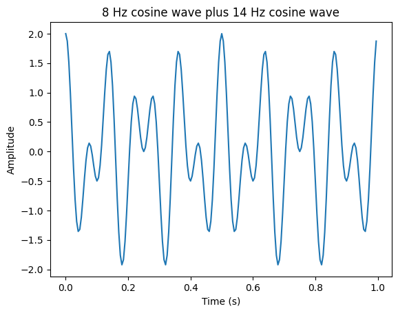

```python
fs = 200
t = np.arange(0,1,1/fs)
freq1 = 8 # Hz
freq2 = 14 # Hz
f = np.cos(2*np.pi*t*freq1) + np.cos(2*np.pi*t*freq2)
plt.plot(t,f); plt.xlabel('Time (s)'); plt.ylabel('Amplitude')
plt.title(str(freq1)+' Hz cosine wave plus '+str(freq2)+' Hz cosine wave')
plt.show()
```

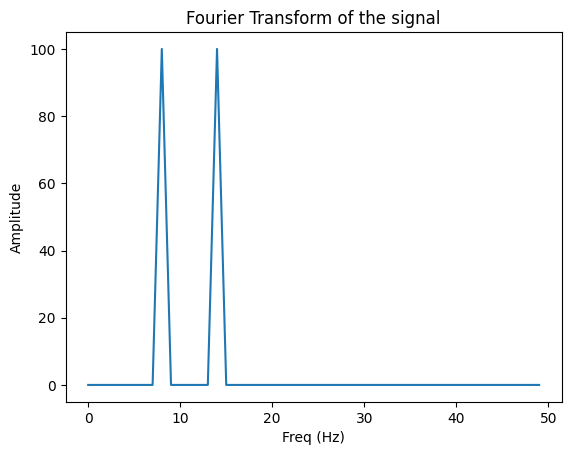

```python
N = len(t);
k = np.arange(0,fs,fs/N)
F = np.fft.fft(f,N)
plt.plot(k[:int(len(k)/4)],F[:int(len(F)/4)])
plt.xlabel('Freq (Hz)')
plt.ylabel('Amplitude')
plt.title('Fourier Transform of the signal')
plt.show()
```

## Forms

*Types of Fourier Transforms*

- Fourier transforms are integral transforms that takes in an arbitrary input function in the time domain and transforms it into the frequency domain.
- They can be continuous or discrete in terms of input time and output frequency and can be across finite or infinite time durations.
- Conventional Fourier transforms work with continuous time and frequency for an infinite duration, which necessitates continuous integrals.

- $\omega$ is the output frequency and $x(t)$ is the continuous time input function
- The complex coefficient actually *simplifies* the equation due to Euler's identity and not needing to find 2 real coefficients for each frequency.

## Forms

*Types of Fourier Transforms*

- For other inputs like images, we can not represent them in terms of continuous functions, so we have to convert the transform to work with discretized inputs.

$$ X(k) = \sum_{n=0}^{N-1} x(n)e^{-j\omega_k n}, k = 0, 1, ..., N - 1 $$

- Each k represents a frequency bin determined by dividing the sampling frequency by the number of samples taken.

## Types of Fourier Transforms [8]

[figure not shown]

## Example

- The slides below illustrate calculating the DFT on a simple sine wave. [9]

```python
def fft(seq, samp_freq, samples):
    bins = np.zeros(samp_freq,dtype=np.complex_)
    for x in range(samples):
        for y in range(samp_freq):
            bins[x] += seq[y] * (np.cos(-2*np.pi*x*y/samples) + 1j*np.sin(-2*np.pi*x*y/samples))
    return bins

def mag(complex_seq):
    return np.sqrt(np.power(complex_seq.real, 2) + np.power(complex_seq.imag, 2))
```

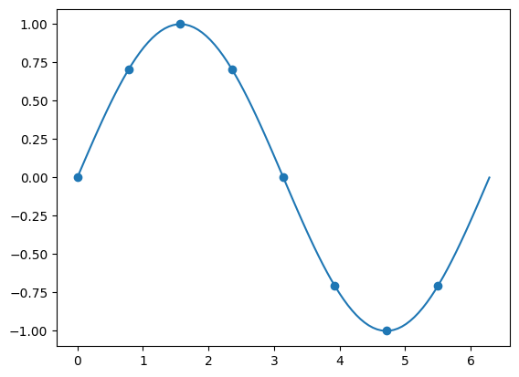

```python
true_x = np.linspace(0, 2*np.pi, 100)
true_y = np.sin(true_x)
plt.plot(true_x, true_y, label="sin(t)")

x_values = np.linspace(0, 2*np.pi, 9)[:-1]
y_values = np.sin(x_values)
plt.scatter(x_values, y_values)
plt.show()
```

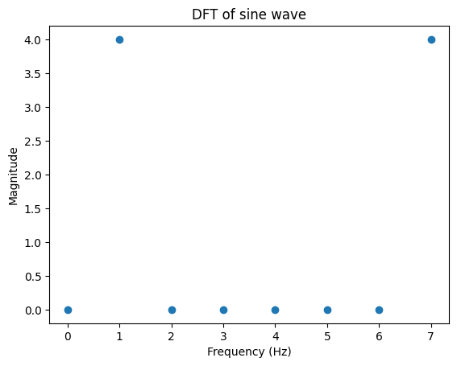

```python
fft_y_values = fft(y_values, 8, 8)

mag_y = mag(fft_y_values)

x_bins = np.linspace(0, 7, 8, dtype=int)
plt.scatter(x_bins, mag_y)
plt.xlabel("Frequency (Hz)")
plt.ylabel("Magnitude")
plt.title("DFT of sine wave")
plt.show()
```

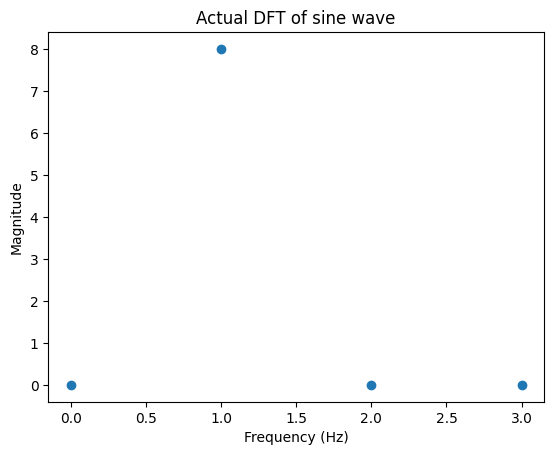

```python
fft_y_values = fft(y_values, 8, 8)
fft_y_values = fft_y_values*2
mag_y = mag(fft_y_values)
mag_y = mag_y[:len(mag_y)//2]

x_bins = np.linspace(0, 7, 8, dtype=int)
x_bins = x_bins[:len(x_bins)//2]
plt.scatter(x_bins, mag_y)
plt.xlabel("Frequency (Hz)")
plt.ylabel("Magnitude")
plt.title("Actual DFT of sine wave")
plt.show()
```

## Things to note

- Potential pitfalls occur when the Nyquist sampling theorem is not followed.
- Aliasing can occur when you do not sample at at least double the frequency of the highest possible frequency found in the input function.
- This higher frequency component can then appear in the DFT result errantly, masking other true frequency components.
- Can apply anti-aliasing filters or raise the sampling frequency.

## Example 2

- The slides below illustrate interesting behaviors when performing FFTs on images.
- Fast Fourier Transforms (FFTs) are just faster algorithms for computing the discrete Fourier Transforms.

```python
img_1_open = Image.open('lena.jpg')
img_2_open = Image.open('baboon.jpg')

img_1 = np.asarray(img_1_open.convert("L"))
img_2 = np.asarray(img_2_open.convert("L"))

#FFT of images
fft_img_1 = np.fft.fft2(img_1)
fft_img_2 = np.fft.fft2(img_2)

#Switching the phase components
phase_angle1 = np.angle(fft_img_1)
phase_angle2 = np.angle(fft_img_2)

new_fft_img_1 = np.abs(fft_img_1) * np.exp(1j * phase_angle2)
new_fft_img_2 = np.abs(fft_img_2) * np.exp(1j * phase_angle1)

#Reconstructing images
ifft_img_1 = np.fft.ifft2(new_fft_img_1).real
ifft_img_2 = np.fft.ifft2(new_fft_img_2).real
```

[figure not shown]

```python
fig, axs = plt.subplots(1, 4)

axs[0].imshow(img_1, cmap="gray")
axs[0].set_title("img_1")

axs[1].imshow(img_2, cmap="gray")
axs[1].set_title("img_2")

axs[2].imshow(ifft_img_1, cmap="gray")
axs[2].set_title("ifft_img_1")

axs[3].imshow(ifft_img_2, cmap="gray")
axs[3].set_title("ifft_img_2")

for i in range(4):
    axs[i].axis('off')

plt.show()
```

```python
img_1_open = Image.open('lena.jpg')
img_2_open = Image.open('baboon.jpg')

img_1 = np.asarray(img_1_open.convert("L"))
img_2 = np.asarray(img_2_open.convert("L"))

#FFT of images
fft_img_1 = np.fft.fft2(img_1)
fft_img_2 = np.fft.fft2(img_2)

#Applying gain and bias to magnitude
phase_angle1 = np.angle(fft_img_1)
phase_angle2 = np.angle(fft_img_2)

gain = 0.5
bias = 10000
new_fft_img_1 = (np.abs(fft_img_1) * gain + bias) * np.exp(1j * phase_angle1)
new_fft_img_2 = (np.abs(fft_img_2) * gain + bias) * np.exp(1j * phase_angle2)

#Reconstructing images
ifft_img_1 = np.fft.ifft2(new_fft_img_1).real
ifft_img_2 = np.fft.ifft2(new_fft_img_2).real
```

[figure not shown]

```python
fig, axs = plt.subplots(1, 4)

axs[0].imshow(img_1, cmap="gray", vmin=0, vmax=255)
axs[0].set_title("img_1")

axs[1].imshow(img_2, cmap="gray", vmin=0, vmax=255)
axs[1].set_title("img_2")

axs[2].imshow(ifft_img_1, cmap="gray", vmin=0, vmax=255)
axs[2].set_title("ifft_img_1")

axs[3].imshow(ifft_img_2, cmap="gray", vmin=0, vmax=255)
axs[3].set_title("ifft_img_2")

for i in range(4):
    axs[i].axis('off')

plt.show()
```

## What's Happening?

- The predominant features of each image gets swapped after switching the phase response before running the inverse FFT.
- The phase contains information regarding how the different frequencies contribute to the structure of the image.
- The magnitude just tells how much each frequency is actually contributing, which means the phase is more important for the overall shape/features of the image.
- Adjusting the gain and bias of the magnitude can brighten or sharpen the image as well, show how FFTs can be used as filters for images.

## FFTs

- The DFT algorithm is unoptimized, so a lot of research has been poured into finding efficient FFT algorithms.
- Butterfly diagrams from the Cooley-Tukey FFT algorithm have been a common way to represent other similar transforms too, such as discrete cosine transforms.

[figure not shown]

*y<sub>0</sub> = x<sub>0</sub> + x<sub>1</sub>*

*y<sub>1</sub> = x<sub>0</sub> - x<sub>1</sub>*

- A butterfly is simply a portion of the computation that combines the results of 2 smaller DFTs or vice versa.
- Apache Imaging Commons actually uses a butterfly diagram implementation of DCT for their JPEG decoder.

## 16 Point Butterfly Diagram

[figure not shown]

## Fourier Neural Operators

*Introduction* [10]

- Fourier transforms are also useful in solving partial differential equations systems.
- In essence, neural operators use neural networks to learn to solution operators for PDEs. So, given the initial or boundary conditions, the neural network can directly output the solution.
- This differs from conventional PDE solvers that need to discretize the space into a fine mesh, whereas the neural operators are mesh-independent.
- The neural operator will learn the continuous function rather than discretized vectors.

## Neural Operators

[figure not shown]

## Fourier Neural Operators

*Introduction* [10]

- We can use CNNs on real-world images well because they normally have edges and shapes that can be captured by convolution kernels.
- The inputs and outputs of PDEs are continuous, however, which is perfect suited for conventional Fourier transforms.
- Fourier transforms are fast and efficient, and convolutions in the spatial domain are equivalent to pointwise multiplication in the Fourier domain.
- A Fourier layer consists of a Fourier transform, then a linear transform, and an inverse Fourier transform.

[figure not shown]

## Fourier Neural Operators

*CNN vs Fourier Filters*

[figure not shown]

## Training a Tensorized Fourier Neural Operator on Darcy-flow Data

[6],[7]

## The Darcy PDE

- The **Darcy Partial Differential Equation** is a second order, elliptic PDE with the following form

[figure not shown]

- *u(x)* describes the flow pressure
- *k(x)* describes the permeability field
- *f* describes the forcing function
- The Darcy PDE is useful for parameterizing flow through porous media, elastic materials and heat conduction.

## Fourier Neural Operators

*Basic concept*

[figure not shown]

Import

```python
import torch
import matplotlib.pyplot as plt
import sys
from neuralop.models import TFNO
from neuralop import Trainer
from neuralop.datasets import load_darcy_flow_small
from neuralop.utils import count_model_params
from neuralop import LpLoss, H1Loss

device = 'cpu'
```

Load the Darcy-flow dataset

```python
train_loader, test_loaders, data_processor = load_darcy_flow_small(
        n_train=3000, batch_size=32,
        test_resolutions=[16, 32], n_tests=[1200, 600],
        test_batch_sizes=[32, 32],
        positional_encoding=True
)
data_processor = data_processor.to(device)
```

```
Loading test db at resolution 32 with 600 samples and batch-size=32
```

Create a tenorized Fourier Neural Operator

```python
model = TFNO(n_modes=(32, 32), hidden_channels=32, projection_channels=64, factorization='tucker', rank=0.42)
model = model.to(device)

n_params = count_model_params(model)
print(f'\nOur model has {n_params} parameters.')
sys.stdout.flush()
```

```
Our model has 2006033 parameters.
```

Create the optimizer

```python
optimizer = torch.optim.Adam(model.parameters(),
                                lr=8e-3,
                                weight_decay=1e-4)
scheduler = torch.optim.lr_scheduler.CosineAnnealingLR(optimizer, T_max=30)
```

Create the losses

```python
l2loss = LpLoss(d=2, p=2)
h1loss = H1Loss(d=2)

train_loss = h1loss
eval_losses={'h1': h1loss, 'l2': l2loss}
```

```python
print('\n### MODEL ###\n', model)
print('\n### OPTIMIZER ###\n', optimizer)
print('\n### SCHEDULER ###\n', scheduler)
print('\n### LOSSES ###')
print(f'\n * Train: {train_loss}')
print(f'\n * Test: {eval_losses}')
sys.stdout.flush()
```

```
### MODEL ###
 TFNO(
  (fno_blocks): FNOBlocks(
    (convs): SpectralConv(
      (weight): ModuleList(
        (0-3): 4 x ComplexTuckerTensor(shape=(32, 32, 32, 17), rank=(26, 26, 26, 14))
      )
    )
    (fno_skips): ModuleList(
      (0-3): 4 x Conv2d(32, 32, kernel_size=(1, 1), stride=(1, 1), bias=False)
    )
  )
  (lifting): MLP(
    (fcs): ModuleList(
      (0): Conv2d(3, 256, kernel_size=(1, 1), stride=(1, 1))
      (1): Conv2d(256, 32, kernel_size=(1, 1), stride=(1, 1))
    )
  )
  (projection): MLP(
    (fcs): ModuleList(
      (0): Conv2d(32, 64, kernel_size=(1, 1), stride=(1, 1))
      (1): Conv2d(64, 1, kernel_size=(1, 1), stride=(1, 1))
    )
  )
)

### OPTIMIZER ###
 Adam (
Parameter Group 0
    amsgrad: False
    betas: (0.9, 0.999)
    capturable: False
    differentiable: False
    eps: 1e-08
    foreach: None
    fused: None
    initial_lr: 0.008
    lr: 0.008
    maximize: False
    weight_decay: 0.0001
)

### SCHEDULER ###
 <torch.optim.lr_scheduler.CosineAnnealingLR object at 0x16a94bed0>

### LOSSES ###

 * Train: <neuralop.losses.data_losses.H1Loss object at 0x316a0ee50>

 * Test: {'h1': <neuralop.losses.data_losses.H1Loss object at 0x316a0ee50>, 'l2': <neuralop.losses.data_losses.LpLoss object at 0x316a0fa50>}
```

Create the trainer

```python
trainer = Trainer(model=model, n_epochs=20,
                  device=device,
                  data_processor=data_processor,
                  wandb_log=False,
                  log_test_interval=3,
                  use_distributed=False,
                  verbose=True)
```

```
self.override_load_to_device=False
self.overrides_loss=False
```

Train the model on the Darcy-flow dataset

```python
trainer.train(train_loader=train_loader,
              test_loaders=test_loaders,
              optimizer=optimizer,
              scheduler=scheduler,
              regularizer=False,
              training_loss=train_loss,
              eval_losses=eval_losses)
```

```
{'32_h1': 0.35632307052612305, '32_l2': 0.21134700775146484}
```

Plot the prediction, and compare with the ground-truth

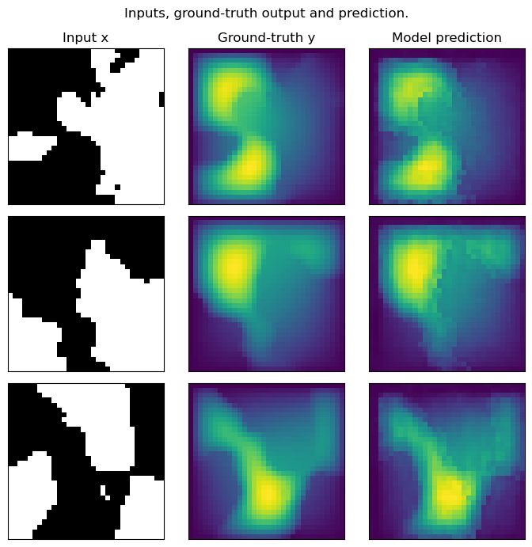

```python
test_samples = test_loaders[32].dataset

fig = plt.figure(figsize=(7, 7))
for index in range(3):
    data = test_samples[index]
    data = data_processor.preprocess(data, batched=False)
    # Input x
    x = data['x']
    # Ground-truth
    y = data['y']
    # Model prediction
    out = model(x.unsqueeze(0))

    ax = fig.add_subplot(3, 3, index*3 + 1)
    ax.imshow(x[0], cmap='gray')
    if index == 0:
        ax.set_title('Input x')
    plt.xticks([], [])
    plt.yticks([], [])

    ax = fig.add_subplot(3, 3, index*3 + 2)
    ax.imshow(y.squeeze())
    if index == 0:
        ax.set_title('Ground-truth y')
    plt.xticks([], [])
    plt.yticks([], [])

    ax = fig.add_subplot(3, 3, index*3 + 3)
    ax.imshow(out.squeeze().detach().numpy())
    if index == 0:
        ax.set_title('Model prediction')
    plt.xticks([], [])
    plt.yticks([], [])

fig.suptitle('Inputs, ground-truth output and prediction.', y=0.98)
plt.tight_layout()
plt.show()
```

[figure not shown]

## References

[1] Valentinuzzi, M. "Highlights in the History of the Fourier Transform." *IEEE Pulse*, 2016. https://www.embs.org/pulse/articles/highlights-in-the-history-of-the-fourier-transform/.  
[2] Flandrin, P. "Fourier and the Early Days of Sound Analysis." *DSP History*, 2023. https://ieeexplore.ieee.org/stamp/stamp.jsp?tp=&arnumber=10313223&tag=1.  
[3] Augustyn, A. "inner ear." *Britannica*. https://www.britannica.com/science/inner-ear.  
[4] Augustyn, A. "phonograph." *Britannica*. https://www.britannica.com/technology/phonograph.  
[5] Smith, J. "Mathematics of the Discrete Fourier Transform (DFT) with Audio Applications." *CCRMA*, 2007. https://ccrma.stanford.edu/~jos/mdft/.  
[6] Li, Z., Kovachki, N., Azizzadenesheli, K., Liu, B., Bhattacharya, K., Stuart, A., and Anandkumar A., “Fourier Neural Operator for Parametric Partial Differential Equations.” *ICLR*, 2021. doi:10.48550/arXiv.2010.08895.  
[7] Kovachki, N., Li, Z., Liu, B., Azizzadenesheli, K., Bhattacharya, K., Stuart, A., and Anandkumar A., “Neural Operator: Learning Maps Between Function Spaces.” *JMLR*, 2021. doi:10.48550/arXiv.2108.08481.  
[8] Smith, J.O. Spectral Audio Signal Processing, [`http://ccrma.stanford.edu/~jos/sasp/`](http://ccrma.stanford.edu/~jos/sasp/), online book, 2011 edition.  
[9] YouTube. (2015, August 3). Discrete fourier transform - simple step by step. YouTube. https://www.youtube.com/watch?v=mkGsMWi_j4Q  
[10] Fourier Neural Operators - Neuraloperator 0.3.0 Documentation. https://neuraloperator.github.io/neuraloperator/dev/user_guide/fno.html.